# Applying the DeltaTraitSDM to a multi-site provenance trial of native Scots pine (*Pinus sylvestris*)

This file documents the process of testing of a number of mixed-effects models, their comparison, and their implementation within a DeltaTraitSDM framework to predict current and future distribution of native Scots pine height across Scotland.

# 1 Climate variables driving height

A number of strategies have been applied to explore the data and try to uncover the climate variables which may be explanatory for height. According to these, factors driving height may be: *degree days below 18*, *precipitation as snow*, *temperature extremes* (warmest and coldest month temperatures, degree days below 0), *frost free period* and when this begins/ends, and temperature difference between coldest and warmest temperatures (*continentality*).

The data is nested Trial/Block/Provenance. Figure 1.1 illustrates that there is variation in height between trials, and also within trials according to provenance. So there is value in fitting a mixed-effects model to explore height, with the random effects structure taking account of the different trials and provenances.

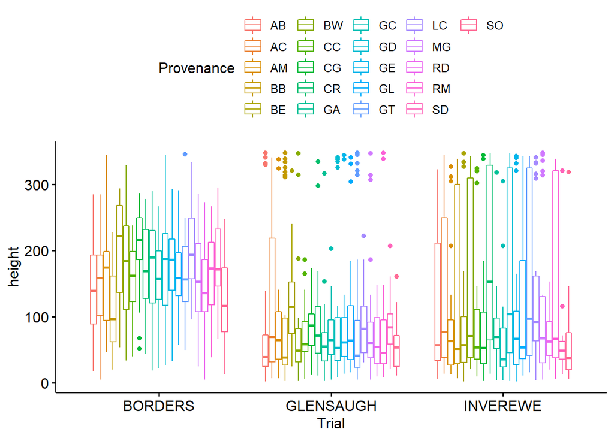

Figure 1.1: Boxplot

Outliers in the data were removed, and checks for normality carried out. As the data is not normal, a Kruskal Wallis test was used to check for significant differences between the mean height of each provenance within each trial. This showed that there are statistically significant differences between provenances within trials (effect size 0.25, p<0.0001), illustrating thate there is both intra-specific genetic variability and phenotypic plasticity in the sample.

## 1.1 Compare model performance

According to the variables highlighted above, several mixed-effects models were generated and compared. Table 1.1 shows a ranked comparison of model metrics for these models. Comparison was carried out using the performance package in R.

[output not shown]

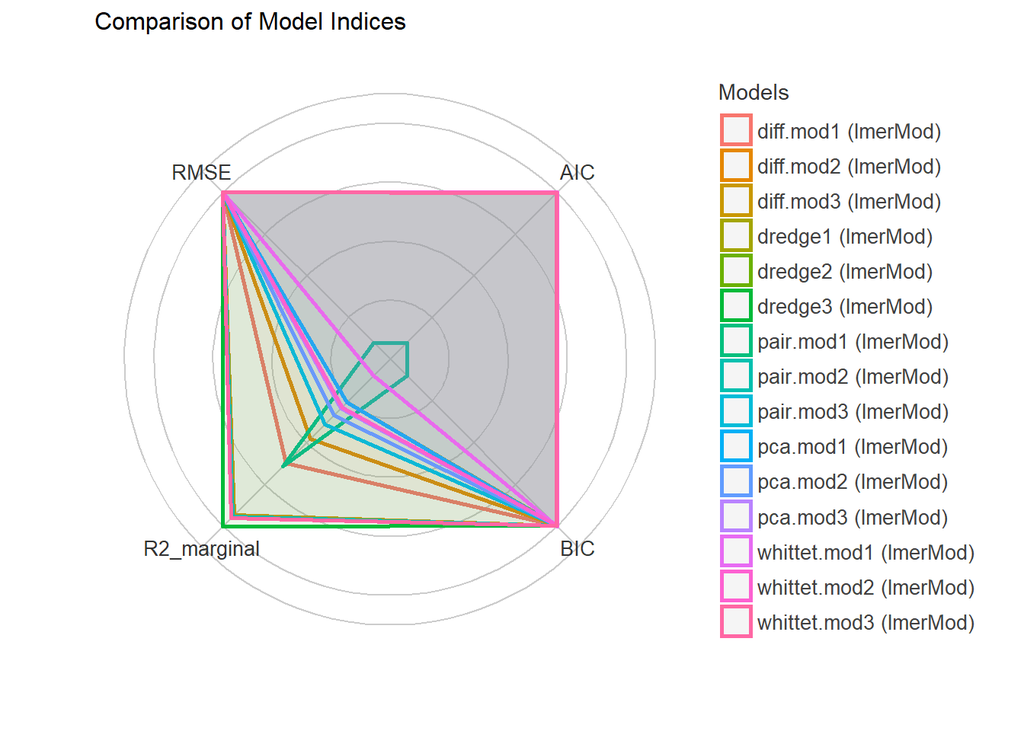

Figure 1.2: A comparison plot of several models

Table 1.1: Comparison of model indices

| Model | Type | AIC | BIC | R2_conditional | R2_marginal | RMSE | ICC | BF |
| --- | --- | --- | --- | --- | --- | --- | --- | --- |
| dredge3 | lmerMod | 4520.223 | 4574.993 | NA | 0.1997338 | 0.8539229 | NA | Inf |
| dredge2 | lmerMod | 4523.683 | 4578.454 | NA | 0.1997338 | 0.8539229 | NA | Inf |
| whittet.mod3 | lmerMod | 4546.459 | 4601.229 | NA | 0.1905853 | 0.8478740 | NA | Inf |
| pair.mod2 | lmerMod | 4535.246 | 4579.063 | NA | 0.1882305 | 0.8483284 | NA | Inf |
| diff.mod3 | lmerMod | 4538.176 | 4581.992 | NA | 0.1869315 | 0.8478419 | NA | Inf |
| diff.mod1 | lmerMod | 4538.584 | 4582.400 | NA | 0.1257286 | 0.8481225 | NA | Inf |
| diff.mod2 | lmerMod | 4538.207 | 4582.023 | NA | 0.0966437 | 0.8482907 | NA | Inf |
| pair.mod3 | lmerMod | 4530.750 | 4574.566 | NA | 0.0793815 | 0.8500159 | NA | Inf |
| pca.mod2 | lmerMod | 4529.375 | 4573.191 | NA | 0.0685224 | 0.8503951 | NA | Inf |
| pca.mod3 | lmerMod | 4528.409 | 4572.225 | NA | 0.0610482 | 0.8506672 | NA | Inf |
| whittet.mod2 | lmerMod | 4531.671 | 4575.487 | NA | 0.0593414 | 0.8499336 | NA | Inf |
| pca.mod1 | lmerMod | 4516.609 | 4560.426 | 0.3371318 | 0.0537258 | 0.8537743 | 0.2994967 | Inf |
| dredge1 | lmerMod | 4524.039 | 4567.856 | 0.3371524 | 0.0533211 | 0.8535492 | 0.2998179 | Inf |
| whittet.mod1 | lmerMod | 4513.926 | 4557.743 | NA | 0.0222534 | 0.8547218 | NA | Inf |
| pair.mod1 | lmerMod | 20790.745 | 20834.561 | 0.1732381 | 0.1289974 | 83.9446688 | 0.0507929 | 1 |

## 1.2 Cross-validation

dredge2 = Height ~ DD_18_T + NFFD_P + PAS_T + DD_18_T x NFFD_P + NFFD_P x PAS_T + (1|Trial/Block/Provenance)

dredge3 = Height ~ DD_18_T + NFFD_P + TD_T + DD_18_T x NFFD_P + NFFD_P x TD_T+ (1|Trial/Block/Provenance)

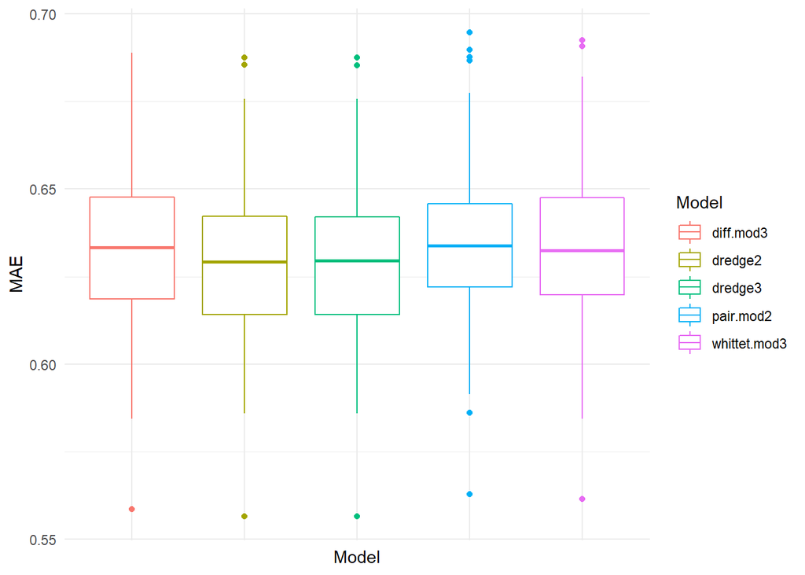

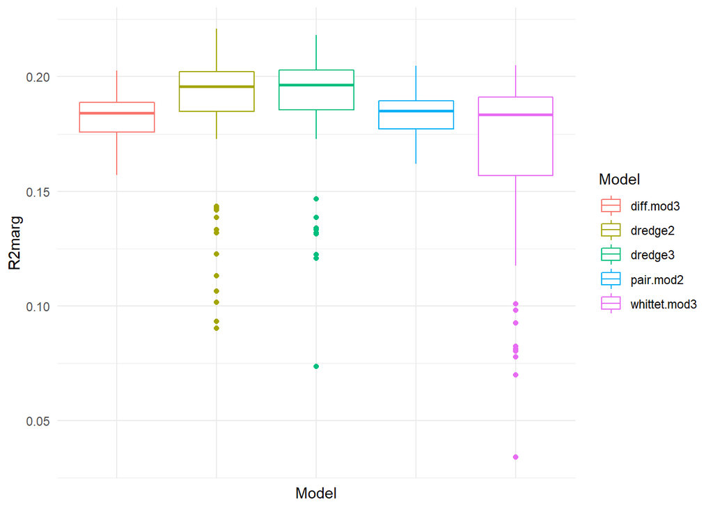

Their table summaries and descriptions are shown below:

[output not shown]

```
## Parameter                    | Coefficient | CI_low | CI_high |    p | Std_Coefficient |  Fit
## ---------------------------------------------------------------------------------------------
## (Intercept)                  |        4.45 |        |         | 0.00 |            1.46 |
## scale(DD_18_T)               |        0.08 |        |         | 0.71 |            0.03 |
## scale(NFFD_P)                |        0.04 |        |         | 0.04 |            0.01 |
## scale(PAS_T)                 |        0.37 |        |         | 0.15 |            0.09 |
## scale(DD_18_T):scale(NFFD_P) |        0.12 |        |         | 0.00 |            0.03 |
## scale(NFFD_P):scale(PAS_T)   |       -0.04 |        |         | 0.09 |           -0.02 |
##                              |             |        |         |      |                 |
## R2 (conditional)             |             |        |         |      |                 |
## R2 (marginal)                |             |        |         |      |                 | 0.20
```

[output not shown]

[output not shown]

```
## Parameter                    | Coefficient | CI_low | CI_high |    p | Std_Coefficient |  Fit
## ---------------------------------------------------------------------------------------------
## (Intercept)                  |        4.45 |        |         | 0.00 |            1.46 |
## scale(DD_18_T)               |       -0.58 |        |         | 0.68 |           -0.13 |
## scale(NFFD_P)                |        0.04 |        |         | 0.04 |            0.01 |
## scale(TD_T)                  |        0.88 |        |         | 0.54 |            0.21 |
## scale(DD_18_T):scale(NFFD_P) |        0.18 |        |         | 0.00 |            0.06 |
## scale(NFFD_P):scale(TD_T)    |       -0.09 |        |         | 0.09 |           -0.04 |
##                              |             |        |         |      |                 |
## R2 (conditional)             |             |        |         |      |                 |
## R2 (marginal)                |             |        |         |      |                 | 0.20
```

[output not shown]

# 2 DeltaTraitSDM

Several approaches were taken when applying the models within DeltaTraitSDM.

Firstly, climate surfaces for the ‘climate normal’ period (an average taken from 1960-1990) were used to estimate distribution.

Secondly, separate climate surfaces were produced for the year when the seed was collected for the provenance trial (2007) and the year the seedlings were planted at the trial site (2012).

Finally, a climate surface representing possible future climate change was used to estimate future distribution.

## 2.1 Predicted distribution for current climate

Figures 2.1 and 2.2 show predicted height distribution for the current climate using the 30yr average climate ‘normal’ for two models.

[figure not shown]

Figure 2.1: Height predicted using 30yr average normal climate (dredge2)

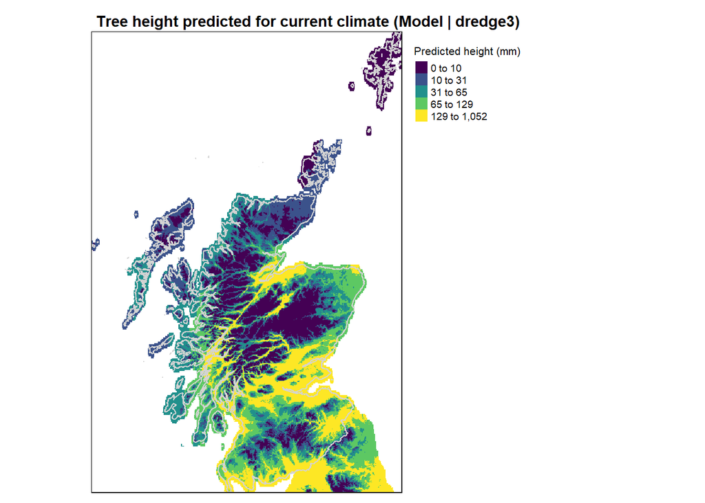

Figure 2.2: Height predicted using 30yr average normal climate (dredge3

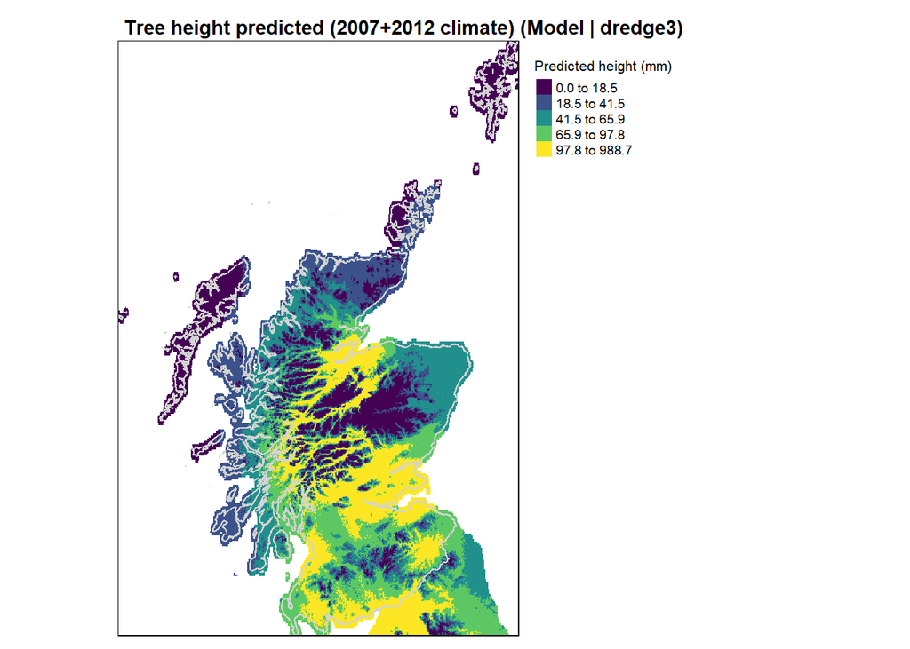

Figure 2.3: Height predicted using climate data from seed collection and planting years

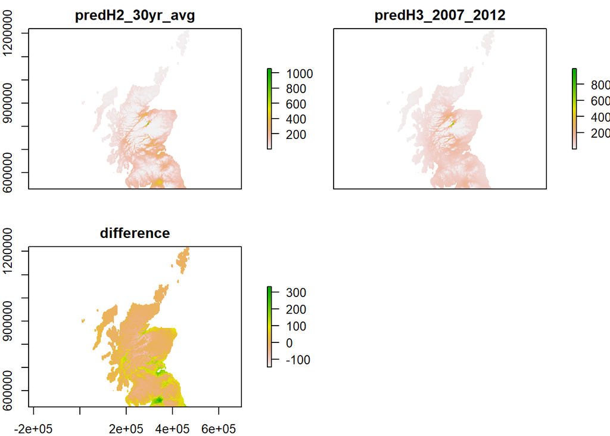

Figure 2.4: Difference between prediction based on climate normal period vs. 2007 and 2012 climate

By using separate rasters for the seed collection and planting years (Figures 2.3 and 2.4) the future height prediction is constrained to a smaller area and predicts lower height overall.

The more accurate/constrained predictions using 2007 and 2012 climate data were then masked using the current distribution of Scots pine taken from the Native Woodland Survey Scotland (Figure 2.5).

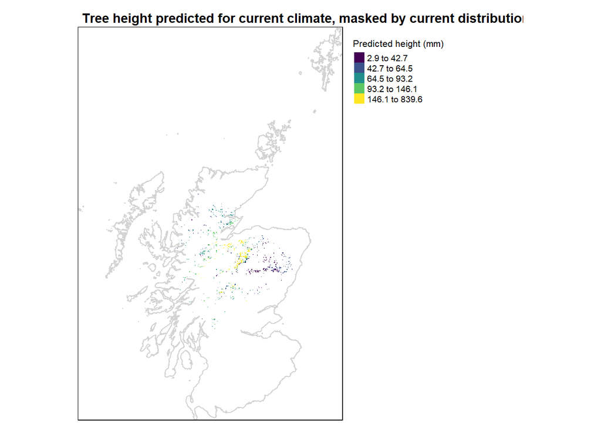

Figure 2.5: Predicted height masked by current distribution of native Scots pine

## 2.2 Predicted distribution under future climate

Figure 2.6 illustrates predicted height distribution for 2050 according to predicted climate for RCP 8.5. Predicted height appears to increase overall and distribution extends - drier, warmer, eastern areas of the UK?

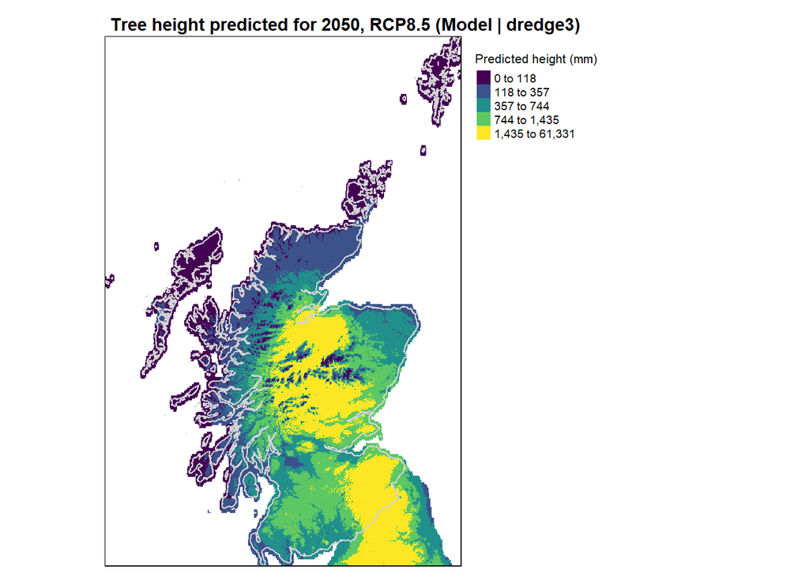

Figure 2.6: Tree height predicted for future climate

# 3 Conclusions and next steps

Very different results from the two ‘best models’. I’ve chosen the one that looks more sensible i.e. closer to the current distribution. Is this valid?

How to I start to model separate provenances/groups of provenances?